# NSF Projects on Databrary

2023-06-27

## Purpose

This document describes the process for providing full funding data for projects shared on Databrary that list the U.S. National Science Foundation as a funding source [^1].

Databrary stores a funding name, and a text field with the award ID, but it does not include the project title, funding amount, or other data related to an award. That data is available, however, from the NSF.

This document uses the `databraryapi` package to extract information about the projects (volumes) that list NSF as a funder and then pulls additional data from the NSF’s data via the NSF API.

Most of the work is done via functions listed in `R/functions.R`.

```r
source("R/functions.R")
```

## Preliminary testing

### Extract NSF-funded projects from Databrary

For efficiency reasons, we test the workflow by limiting the number of Databrary volumes queried.

The following chunks have been disabled (`eval = FALSE`).

```r
vols_1_200 <- get_multiple_vol_nsf_awards(1:200)
```

```r
vols_1_200 |>
  dplyr::select(vol_id, award) |>
  knitr::kable(format = 'html') |>
  kableExtra::kable_material()
```

### Extract details from NSF

```r
vols_1_200_clean <- add_clean_nsf_award_id(vols_1_200)
```

```r
nsf_vols_1_200 <- get_mult_nsf_awards(vols_1_200_clean$award_id)
```

```r
nsf_vols_1_200 |>
  dplyr::select(-agency) |>
  dplyr::arrange(awardeeName, desc(date)) |>
  knitr::kable(format = 'html') |>
  kableExtra::kable_material() |>
  kableExtra::scroll_box(width = "600px", height = "300px")
```

### Save data

```r
readr::write_csv(nsf_vols_1_200, "csv/databrary-nsf-funding-details-TEST.csv")
readr::write_csv(vols_1_200_clean, "csv/databrary-vols-w-nsf-funding-TEST.csv")
```

### Visualize data

```r
nsf_vols_1_200 |>
  dplyr::mutate(award_amt = as.numeric(fundsObligatedAmt)) |>
  ggplot2::ggplot() +
  ggplot2::aes(award_amt) +
  ggplot2::geom_histogram(bins=10)
```

## Full dataset

### Re-import

We re-import the saved data for visualizations if `params$import_saved` == TRUE`.

```r
db_nsf <- readr::read_csv("csv/databrary-vols-w-nsf-funding-all.csv", show_col_types = FALSE)
nsf <- readr::read_csv("csv/databrary-nsf-funding-details-all.csv", show_col_types = FALSE)
```

### Extract NSF-funded projects from Databrary

If `params$import_saved` == FALSE`, we regenerate the data.

```r
message("Regenerating all data.")
```

```
## Regenerating all data.
```

```r
message("Gathering NSF-funded projects from Databrary.")
```

```
## Gathering NSF-funded projects from Databrary.
```

```r
db_nsf <- get_multiple_vol_nsf_awards(1:params$max_vol_id, vb = params$vb)
```

```
## ■ 1% | ETA: 2m
```

[output not shown]

[output cut: 972 more lines]

[output not shown]

```r
db_nsf <- add_clean_nsf_award_id(db_nsf)
```

```r
db_nsf |>
  dplyr::select(vol_id, award) |>
  knitr::kable(format = 'html') |>
  kableExtra::kable_material() |>
  kableExtra::scroll_box(width = "600px", height = "300px")
```

| vol_id | award |
| --- | --- |
| 1 | BCS-1238599 |
| 2 | BCS-1147440 |
| 8 | 0721383 |
| 11 | BCS-1349044 |
| 15 | INT-0808767 |
| 15 | 1052736 |
| 23 | BCS-1147440 |
| 30 | BCS-1247590 |
| 31 | BCS-00-92452 |
| 32 | BCS-00-92452 |
| 45 | BCS-1147543 |
| 49 | BCS-1147440 |
| 68 | BCS-1147440 |
| 73 | BCS-1147440 |
| 75 | BCS-1147440 |
| 77 | IIS-1248076 |
| 79 | BCS-1331073 |
| 81 | BCS-1147440 |
| 109 | 1220305 |
| 116 | BCS-1147440 |
| 207 | BCS-1929935 |
| 207 | BCS-1661068 |
| 218 | BCS-1147440 |
| 253 | BCS-1929935 |
| 253 | BCS-1661068 |
| 268 | BCS-15233982 |
| 269 | BCS-1929935 |
| 269 | NSF BCS-166106 |
| 272 | DGE1255832 |
| 273 | Bonawitz: NSF Choosing to Learn |
| 324 | IIS-1248076 |
| 471 | NSF/SBE-BSF-1627993 |
| 480 | 1561182 |
| 480 | 1561122 |
| 545 | BCS-1056805 |
| 546 | BCS-1056805 |
| 546 | BCS-1560810 |
| 608 | 1560810 |
| 707 | NSF BCS1627993 |
| 950 | BCS-1929935 |
| 950 | BCS-1661068 |
| 987 | 1620294 (2016-2020) |
| 987 | IBSS-L: Continuous Measurement of Children’s Behavior and the Development of Social Dynamics |
| 1062 | 1462280 |
| 1062 | 1400802 |
| 1062 | 1400810 |
| 1116 | 1627993 |
| 1135 | 1302741 |
| 1187 | BCS-1655300 |
| 1241 | IRB-FY2017-722 |
| 1249 | 1462280 |
| 1279 | 1749376 |
| 1294 | BCS 0951580 |
| 1398 | 2043717 |
| 1403 | NSF #1761053 Collaborative Research: Math Cognition in Toddlers from Latine and White Families |
| 1403 | Robin Hood Foundation: Routine Language in Hispanic Families |
| 1437 | [BCS-1056805 |
| 1437 | BCS-1560810 |
| 1437 | CS-1728133 |
| 1474 | 1052736 |
| 1495 | NSF 1628300 |
| 1550 | 1444758 |
| 1550 | 1948790 |
| 1580 | BCS #1941449 |
| 1589 | 2004983 |

### Extract details from NSF

```r
message("Adding funding details from NSF.gov")
```

```
## Adding funding details from NSF.gov
```

```r
nsf <- get_mult_nsf_awards(db_nsf$award_id, vb = params$vb)
```

```
## ■■ 5% | ETA: 28s
```

[output not shown]

[output cut: 86 more lines]

[output not shown]

### Clean data

```r
nsf <- nsf |>
  dplyr::mutate(awardeeCity = stringr::str_to_title(awardeeCity))
```

```r
nsf |>
  dplyr::select(-agency) |>
  dplyr::arrange(awardeeName, desc(date)) |>
  knitr::kable(format = 'html') |>
  kableExtra::kable_material() |>
  kableExtra::scroll_box(width = "600px", height = "300px")
```

| awardeeCity | awardeeName | awardeeStateCode | fundsObligatedAmt | id | piFirstName | piLastName | publicAccessMandate | date | title |
| --- | --- | --- | --- | --- | --- | --- | --- | --- | --- |
| Providence | Brown University | RI | 817795 | 1661068 | David | Sobel | 1 | 05/01/2017 | Young children’s beliefs about causal systems: Learning about belief revision in the lab and in museums |
| Providence | Brown University | RI | 817795 | 1661068 | David | Sobel | 1 | 05/01/2017 | Young children’s beliefs about causal systems: Learning about belief revision in the lab and in museums |
| Providence | Brown University | RI | 817795 | 1661068 | David | Sobel | 1 | 05/01/2017 | Young children’s beliefs about causal systems: Learning about belief revision in the lab and in museums |
| New York | CUNY City College | NY | 565918 | 1400802 | YingLi | Tian | 0 | 06/26/2014 | CHS: Medium: Collaborative Research: Immediate Feedback to Support Learning American Sign Language through Multisensory Recognition |
| Staten Island | CUNY College of Staten Island | NY | 77355 | 1349044 | Lana | Karasik | 0 | 01/22/2014 | Effects Of Traditional Cradling Practices On Infants’ Physical, Motor, And Social Development |
| New York | CUNY Hunter College | NY | 120000 | 1400810 | Elaine | Gale | 0 | 06/26/2014 | CHS: Medium: Collaborative Research: Immediate Feedback to Support Learning American Sign Language through Multisensory Recognition |
| Fort Collins | Colorado State University | CO | 12741385 | 1444758 | Mazdak | Arabi | 0 | 07/28/2015 | SRN: Urban Water Innovation Network (U-WIN): Transitioning Toward Sustainable Urban Water Systems |
| Princeton | Kosie, Jessica Elizabeth | NJ | 69000 | 2004983 | Jessica | Kosie | 1 | 06/30/2020 | Neural and behavioral coordination in infant-caregiver communication across the socioeconomic spectrum |
| East Lansing | Michigan State University | MI | 254004 | 1561122 | Kimberly | Fenn | 0 | 08/30/2016 | Collaborative Research: Cognitive Mechanisms of Early Math Learning - Improving Outcomes by Harnessing Multiple Memory Representations |
| Boston | Museum of Science | MA | 2999827 | 1220305 | Christine | Cunningham | 0 | 09/06/2012 | Exploring the Efficacy of Engineering is Elementary (E4) |
| New York | New York University | NY | 2665719 | 1238599 | Karen | Adolph | 0 | 09/25/2012 | Databrary: An open video-based data-sharing system for developmental science |
| New York | New York University | NY | 600000 | 1761053 | Catherine | Tamis-LeMonda | 1 | 08/22/2018 | Collaborative Research: Math Cognition In Toddlers From Latino and White Families: Contributions Of Home Experiences With Mothers and Fathers |
| New York | New York University | NY | 2500000 | 0721383 | Catherine | Tamis-LeMonda | 0 | 08/07/2007 | IRADS: The Study of Culture, Social Settings, and Child Development across School Transitions |
| New York | New York University | NY | 293783 | 1627993 | Karen | Adolph | 0 | 07/27/2016 | NSF/SBE-BSF: Neural patterns underlying the development of planning in action production and anticipation in action perception |
| New York | New York University | NY | 293783 | 1627993 | Karen | Adolph | 0 | 07/27/2016 | NSF/SBE-BSF: Neural patterns underlying the development of planning in action production and anticipation in action perception |
| New York | New York University | NY | 293783 | 1627993 | Karen | Adolph | 0 | 07/27/2016 | NSF/SBE-BSF: Neural patterns underlying the development of planning in action production and anticipation in action perception |
| New York | New York University | NY | 337975 | 1147543 | Marjorie | Rhodes | 0 | 07/12/2012 | The role of within-category variability in the development of induction |
| New York | New York University | NY | 495472 | 2043717 | David | Poeppel | 1 | 02/23/2021 | Audiomotor Speech Rhythms and Their Perceptual Consequences |
| Boston | Northeastern University | MA | 234794 | 1948790 | Laura | Senier | 1 | 03/30/2020 | Water Unaffordability in the United States: Using Principles of Organizational Learning to Understand Municipal Capacity to Safeguard Water Access |
| University Park | Pennsylvania State Univ University Park | PA | 800000 | 1248076 | Yanxi | Liu | 0 | 09/09/2012 | INSPIRE: Symmetry Group-based Regularity Perception in Human and Computer Vision |
| University Park | Pennsylvania State Univ University Park | PA | 800000 | 1248076 | Yanxi | Liu | 0 | 09/09/2012 | INSPIRE: Symmetry Group-based Regularity Perception in Human and Computer Vision |
| University Park | Pennsylvania State Univ University Park | PA | 11668917 | 1255832 | Michael | Verderame | 0 | 08/12/2012 | Graduate Research Fellowship Program (GRFP) |
| University Park | Pennsylvania State Univ University Park | PA | 354257 | 1331073 | Bradley | Wyble | 0 | 07/27/2013 | Integrating Spatial and Temporal Models of Visual Attention |
| University Park | Pennsylvania State Univ University Park | PA | 385000 | 1147440 | Rick | Gilmore | 0 | 06/05/2012 | The Development and Dynamics of Cortical Motion Processing |
| University Park | Pennsylvania State Univ University Park | PA | 385000 | 1147440 | Rick | Gilmore | 0 | 06/05/2012 | The Development and Dynamics of Cortical Motion Processing |
| University Park | Pennsylvania State Univ University Park | PA | 385000 | 1147440 | Rick | Gilmore | 0 | 06/05/2012 | The Development and Dynamics of Cortical Motion Processing |
| University Park | Pennsylvania State Univ University Park | PA | 385000 | 1147440 | Rick | Gilmore | 0 | 06/05/2012 | The Development and Dynamics of Cortical Motion Processing |
| University Park | Pennsylvania State Univ University Park | PA | 385000 | 1147440 | Rick | Gilmore | 0 | 06/05/2012 | The Development and Dynamics of Cortical Motion Processing |
| University Park | Pennsylvania State Univ University Park | PA | 385000 | 1147440 | Rick | Gilmore | 0 | 06/05/2012 | The Development and Dynamics of Cortical Motion Processing |
| University Park | Pennsylvania State Univ University Park | PA | 385000 | 1147440 | Rick | Gilmore | 0 | 06/05/2012 | The Development and Dynamics of Cortical Motion Processing |
| University Park | Pennsylvania State Univ University Park | PA | 385000 | 1147440 | Rick | Gilmore | 0 | 06/05/2012 | The Development and Dynamics of Cortical Motion Processing |
| University Park | Pennsylvania State Univ University Park | PA | 385000 | 1147440 | Rick | Gilmore | 0 | 06/05/2012 | The Development and Dynamics of Cortical Motion Processing |
| University Park | Pennsylvania State Univ University Park | PA | 397307 | 0092452 | Rick | Gilmore | 0 | 02/09/2001 | CAREER: The Development of Heading Perception in Infancy |
| University Park | Pennsylvania State Univ University Park | PA | 397307 | 0092452 | Rick | Gilmore | 0 | 02/09/2001 | CAREER: The Development of Heading Perception in Infancy |
| University Park | Pennsylvania State Univ University Park | PA | 460814 | 1302741 | Michelle | Vigeant | 0 | 01/25/2013 | CAREER: Importance of Late-Sound-Field Properties and Listener Envelopment to Room Acoustic Quality and Design |
| Rochester | Rochester Institute of Tech | NY | 537997 | 1462280 | Matt | Huenerfauth | 0 | 09/15/2014 | CHS: Medium: Collaborative Research: Immediate Feedback to Support Learning American Sign Language through Multisensory Recognition |
| Rochester | Rochester Institute of Tech | NY | 537997 | 1462280 | Matt | Huenerfauth | 0 | 09/15/2014 | CHS: Medium: Collaborative Research: Immediate Feedback to Support Learning American Sign Language through Multisensory Recognition |
| Rochester | Rochester Institute of Tech | NY | 349882 | 1749376 | Matthew | Dye | 1 | 05/17/2018 | Collaborative Research: Multimethod Investigation of Articulatory and Perceptual Constraints on Natural Language Evolution |
| Newark | Rutgers University Newark | NJ | 284473 | 1247590 | Vanessa | LoBue | 0 | 05/22/2013 | Validation of the Child Affective Facial Expressions Set (CAFE) |
| Davis | University of California-Davis | CA | 305523 | 0951580 | Lisa | Oakes | 0 | 08/26/2010 | Experience and cognitive development in infancy |
| Los Angeles | University of California-Los Angeles | CA | 555792 | 1655300 | Hongjing | Lu | 1 | 04/05/2017 | Discovering Hierarchical Representations for Action Understanding |
| Riverside | University of California-Riverside | CA | 631076 | 1941449 | John | Franchak | 1 | 07/21/2020 | Developmental cascades: How motor development alters everyday learning experiences |
| La Jolla | University of California-San Diego | CA | 2650000 | 0808767 | Javier | Movellan | 0 | 08/26/2008 | INT2-Large: Collaborative Research: Developing Social Robots |
| Chicago | University of Chicago | IL | 377342 | 1628300 | Amanda | Woodward | 0 | 08/18/2016 | Collaborative Research: Action, Learning, and Social Cognition |
| Gainesville | University of Florida | FL | 202503 | 1560810 | Lisa | Scott | 0 | 09/18/2015 | CAREER:Perceptual Narrowing and Cortical Development in Infancy |
| Gainesville | University of Florida | FL | 202503 | 1560810 | Lisa | Scott | 0 | 09/18/2015 | CAREER:Perceptual Narrowing and Cortical Development in Infancy |
| Gainesville | University of Florida | FL | 202503 | 1560810 | Lisa | Scott | 0 | 09/18/2015 | CAREER:Perceptual Narrowing and Cortical Development in Infancy |
| Gainesville | University of Florida | FL | 516424 | 1728133 | Lisa | Scott | 1 | 07/07/2017 | Reliable and Robust Infant Brain Responses During Face Learning |
| Iowa City | University of Iowa | IA | 249592 | 1561182 | Susan | Cook | 0 | 08/30/2016 | Collaborative Research: Cognitive Mechanisms of Early Math Learning - Improving Outcomes by Harnessing Multiple Memory Representations |
| Amherst | University of Massachusetts Amherst | MA | 472086 | 1056805 | Lisa | Scott | 0 | 07/20/2011 | CAREER:Perceptual Narrowing and Cortical Development in Infancy |
| Amherst | University of Massachusetts Amherst | MA | 472086 | 1056805 | Lisa | Scott | 0 | 07/20/2011 | CAREER:Perceptual Narrowing and Cortical Development in Infancy |
| Amherst | University of Massachusetts Amherst | MA | 472086 | 1056805 | Lisa | Scott | 0 | 07/20/2011 | CAREER:Perceptual Narrowing and Cortical Development in Infancy |
| Coral Gables | University of Miami | FL | 869999 | 1620294 | Daniel | Messinger | 0 | 08/12/2016 | IBSS-L: Continuous Measurement of Children’s Behavior and the Development of Social Dynamics |
| Coral Gables | University of Miami | FL | 202002 | 1052736 | Daniel | Messinger | 0 | 06/14/2011 | Collaborative Research: Communication, Perturbation, and Early Development |
| Coral Gables | University of Miami | FL | 202002 | 1052736 | Daniel | Messinger | 0 | 06/14/2011 | Collaborative Research: Communication, Perturbation, and Early Development |
| Villanova | Villanova University | PA | 482889 | 1929935 | DEENA | WEISBERG | 1 | 04/09/2019 | Young children’s beliefs about causal systems: Learning about belief revision in the lab and in museums |
| Villanova | Villanova University | PA | 482889 | 1929935 | DEENA | WEISBERG | 1 | 04/09/2019 | Young children’s beliefs about causal systems: Learning about belief revision in the lab and in museums |
| Villanova | Villanova University | PA | 482889 | 1929935 | DEENA | WEISBERG | 1 | 04/09/2019 | Young children’s beliefs about causal systems: Learning about belief revision in the lab and in museums |
| Villanova | Villanova University | PA | 482889 | 1929935 | DEENA | WEISBERG | 1 | 04/09/2019 | Young children’s beliefs about causal systems: Learning about belief revision in the lab and in museums |

### Save data

```r
readr::write_csv(nsf, "csv/databrary-nsf-funding-details-all.csv")
readr::write_csv(db_nsf, "csv/databrary-vols-w-nsf-funding-all.csv")
```

### Visualize

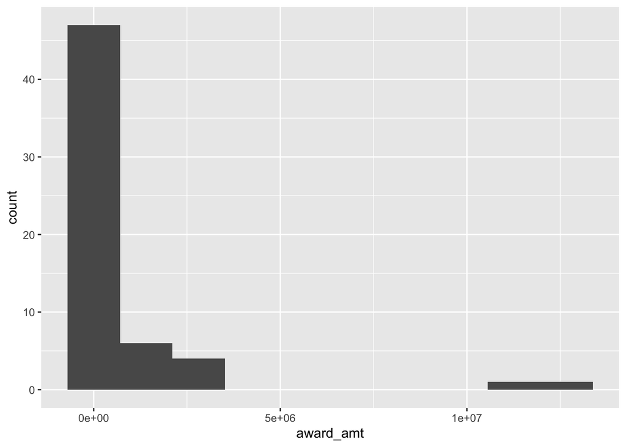

Histogram of NSF awards for all Databrary volumes.

```r
nsf |>
  dplyr::mutate(award_amt = as.numeric(fundsObligatedAmt)) |>
  ggplot2::ggplot() +
  ggplot2::aes(award_amt) +
  ggplot2::geom_histogram(bins=10)
```

There are $n=$ 65 Databrary volumes that list NSF as a funder.

These represent $n=$ 39 unique NSF awards.

Of these, we were able to extract data from the NSF API for $n=$ 36 NSF awards.

The following volumes do not have matching NSF awards.

```r
db_not_found_in_nsf <- !(db_nsf$award_id %in% nsf$id)

db_nsf |>
  dplyr::filter(db_not_found_in_nsf) |>
  dplyr::select(vol_id, award) |>
  knitr::kable(format = 'html') |>
  kableExtra::kable_material() |>
  kableExtra::scroll_box(width = "600px", height = "300px")
```

| vol_id | award |
| --- | --- |
| 268 | BCS-15233982 |
| 269 | NSF BCS-166106 |
| 273 | Bonawitz: NSF Choosing to Learn |
| 987 | IBSS-L: Continuous Measurement of Children’s Behavior and the Development of Social Dynamics |
| 1241 | IRB-FY2017-722 |
| 1403 | Robin Hood Foundation: Routine Language in Hispanic Families |

A next step would be to identify the PIs on these volumes and contact them.

## Cleanup

```r
databraryapi::logout_db()
```

```
## Logout Successful.
```

```
## [1] TRUE
```

[^1]: In a form that permits us to query the NSF API.